# **12 – Projeto de compensadores: método do lugar das raízes**

• Compensadoravançoatraso, 𝛽 = 𝛾 > 1:

$$$$$$ G_{c}(s) = K_{c}\frac{(T_{1}s + 1)(T_{2}s + 1)}{(\frac{T_{1}}{\beta}s + 1)(\beta T_{2}s + 1)} $$$$$$

• O sistema deve possuir polos dominantes com $\xi = 0.5$ • Para cancelar o poloem $s = −1$, o compensador avanço deve possuir um zero em $s = −1$, logo:

$$$$$$ \frac{1}{T_{1}} = 1 ⇒ T_{1} = 1$$$$$$

• Requisito de erro estacionário:

$$$$$$ K'_{v} = \frac{1}{e_{ss}} = \frac{1}{0.02} = 50$$$$$$

• Planta com controlador:

$$$$$$ K'_{v} = \lim_{s->0}K_{c}K_{v} $$$$$$$$K_{c} = \frac{K'_{v}}{K_{v}} = \frac{50}{0.2} = 250 $$$$$$

• Escolhendo o polo do compensador atraso em $s = −0.01$

$$$$$$ \beta\ T_{2}s + 1 = 0$$$$$$$$ \beta\ T_{2}(-0.01) + 1 = 0$$$$$$$$ T_{2}=\frac{1}{\beta\ 0.01} = \frac{100}{\beta}$$$$$$

• Assim, a função de transferência do compensador é: $$$$ $$ G_{c}(s) = 250\frac{(s + 1)(\frac{100}{\beta}s + 1)}{(\frac{1}{\beta}s + 1)(100s + 1)} $$ $$$$ • Variando $\beta$, observa-se no rootlocus a condição para qual os polos dominantes sejam situados em $\xi = 0.5$ para $K_{c} = 250$

```python
s = sp.symbols('s')

beta = 16.25
Kc   = 250
csi  = 0.5

Gcs = Kc*((s + 1)*(100*s/beta + 1))/((s/beta + 1)*(100*s + 1))
Gs = 1/(s*(s + 1)*(s + 5))

GcGs = Gs*Gcs
sp.expand(GcGs)
```

$\displaystyle \frac{1538.46153846154 s}{6.15384615384615 s^{4} + 130.830769230769 s^{3} + 501.307692307692 s^{2} + 5 s} + \frac{250}{6.15384615384615 s^{4} + 130.830769230769 s^{3} + 501.307692307692 s^{2} + 5 s}$

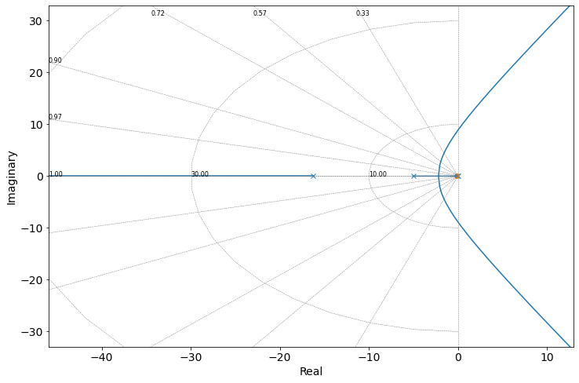

```python
GcGs = clt.tf([1538.46, 250], [6.154, 130.83, 501.31, 5, 0])
root_locus(GcGs)
```

```python
GcGs = (Gs*Gcs)/(1+Gs*Gcs)
sp.factor(GcGs, s)
```

$\displaystyle \frac{0.99676052828308 \left(1.0 s + 0.1625\right)}{0.00398704211313232 s^{4} + 0.0847645153251931 s^{3} + 0.324794418141042 s^{2} + 1.0 s + 0.161973585846}$

```python
sp.expand(0.99676052828308*(1.0*𝑠+0.1625))
```

$\displaystyle 0.99676052828308 s + 0.161973585846001$

```
No handles with labels found to put in legend.
```

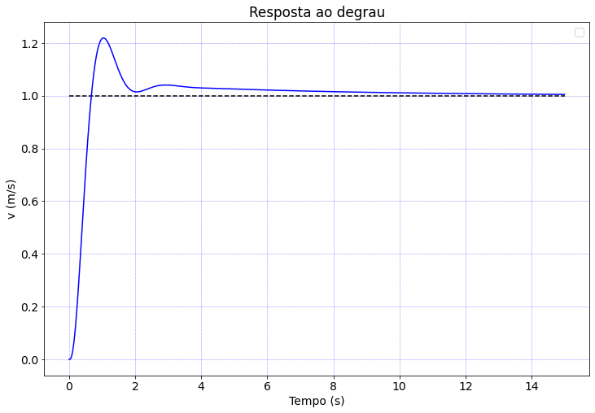

```python
# vetor de tempo
dt = 1e-3
tr  = np.arange(0, 15, dt) # tempo (0 a 20s)

numerador   = [1, 0.162]
denominador = [0.004, 0.085, 0.325, 1, 0.162]

Fs = (numerador, denominador)

LTI = lti(numerador, denominador) # gerando o sistema

t_step, y_step = step(LTI, T=tr)      # resposta ao degrau

plt.hlines(1, 0, 15, linestyles='dashed')
plt.plot(t_step, y_step, color='Blue')
#plt.ylim([0,20])
#plt.xlim([0,20])
plt.xlabel('Tempo (s)')
plt.ylabel('v (m/s)')
plt.grid(color = 'b', alpha = 0.5, linestyle = 'dashed', linewidth = 0.5)
plt.title('Resposta ao degrau')
plt.legend()
plt.show()
```

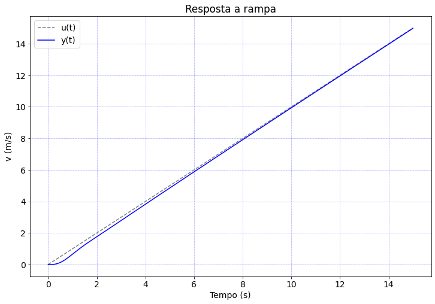

```python
# # vetor de tempo
# dt = 1e-3
# tr  = np.arange(0, 15, dt) # tempo (0 a 20s)

# numerador   = [0.0123, 0.0019]
# denominador = [0.012, 0.261, 1, 0.022, 0.0019]

# Fs = (numerador, denominador)

u = tr

t_step, y_step, x = lsim(Fs, u, tr)

plt.plot(u, u, color='gray', linestyle='dashed', label='u(t)')
plt.plot(t_step, y_step, color='Blue', label='y(t)')
#plt.ylim([0,20])
#plt.xlim([0,20])
plt.xlabel('Tempo (s)')
plt.ylabel('v (m/s)')
plt.grid(color = 'b', alpha = 0.5, linestyle = 'dashed', linewidth = 0.5)
plt.title('Resposta a rampa')
plt.legend()
plt.show()
```